# Modeling File

# Introduction

In this Final Project, I am going to be using a dataset I found on Basketball Reference: [2025-26 NBA Player Stats: Totals](https://www.basketball-reference.com/leagues/NBA_2026_per_minute.html). The dataset features data from the 2025-2026 NBA season. Note that I am interested in predicting the number of minutes played and, since the website would only allow me to retrieve the top 500 players, I sorted by that variable before exporting the file.

A few notes to make on the data: First, I’m interested in what is more likely to earn a player playing time but I wanted to control for injuries so I created a column in the dataset which calculated my actual response variable: minutes played per game (`MPG`). Next, there were “missing” values in the 3 point percentage column (`3P%`) that reflected players that didn’t attempt a 3 point shot (players who attempted at least one, but didn’t make any, already had a value of `0` here). I added `0`’s in the places with missing cells, but I plan on using the `3P` column (made 3 point shots per 36 minutes played) so it should not make a difference in my analysis. Finally, I chose to export the data on a per 36 minutes basis, as cumulative total statistics will be heavily influenced by total minutes played.

There are obviously a lot of player statistics that get tracked but I am going to focus on the following predictor variables (again, with the exception of position, all measured per 36 minutes played): three point shots made (`3P`), free throws made (`FT`), total rebounds (`TRB`), assists(`AST`), steals (`STL`), blocks (`BLK`), turnovers (`TOV`), personal fouls (`PF`), points (`PTS`), and position (`Pos`). Note that some of these are often combined in the analysis of NBA players (for instance, often a player’s assist to turnover ratio or “stocks” [steals+blocks]). I thought combining these might deprive the model of some information (in exchange for having fewer variables, which I thought would be negligibly helpful), so I left them separate.

# Reading in data, setting up libraries

Next, I will read in the data set and load the libraries I’ll need for the modeling process.

```r
# Load packages for data preparation, visualization, and modeling
library(lubridate)
library(tidyverse)
library(ggplot2)
library(tidymodels)
library(ranger)

#Create data tibble

min_played<-read_csv("../2025-26_NBA_Player_Stats_Per_36.csv")

min_played
```

```
# A tibble: 500 × 32
      Rk Player        Age Team  Pos       G    GS    MP   MPG    FG   FGA `FG%`
   <dbl> <chr>       <dbl> <chr> <chr> <dbl> <dbl> <dbl> <dbl> <dbl> <dbl> <dbl>
 1     1 Amen Thomp…    23 HOU   PG       79    79  2953  37.4   6.8  12.7 0.534
 2     2 Kevin Dura…    37 HOU   SF       78    78  2840  36.4   9.1  17.4 0.52
 3     3 Desmond Ba…    27 ORL   SG       82    82  2756  33.6   7.6  15.7 0.484
 4     4 Toumani Ca…    25 POR   PF       82    82  2731  33.3   5.2  11.7 0.44
 5     5 Jabari Smi…    22 HOU   PF       77    77  2705  35.1   5.8  13   0.45
 6     6 Mikal Brid…    29 NYK   SF       82    82  2692  32.8   6.3  12.9 0.49
 7     7 Scottie Ba…    24 TOR   PF       80    80  2681  33.5   7.6  15.1 0.507
 8     8 Tyrese Max…    25 PHI   PG       70    70  2661  38.0   9.4  20.3 0.462
 9     9 Jamal Murr…    28 DEN   PG       75    75  2652  35.4   8.9  18.5 0.483
10    10 Derrick Wh…    31 BOS   PG       77    77  2625  34.1   6    15.2 0.394
# ℹ 490 more rows
# ℹ 20 more variables: `3P` <dbl>, `3PA` <dbl>, `3P%` <dbl>, `2P` <dbl>,
#   `2PA` <dbl>, `2P%` <dbl>, `eFG%` <dbl>, FT <dbl>, FTA <dbl>, `FT%` <dbl>,
#   ORB <dbl>, DRB <dbl>, TRB <dbl>, AST <dbl>, STL <dbl>, BLK <dbl>,
#   TOV <dbl>, PF <dbl>, PTS <dbl>, Awards <chr>
```

Note that there there was very little pre-processing that needed to be done, and it was accomplished before reading the data in.

Another important thing to mention is that we’re dealing with numeric variables across the board here, with the exception of `Pos`, and all the columns are already formatted properly. The one thing I will need to do, though, is create factors for the position data.

```r
#Establish position categories
pos_levels <- unique(min_played$Pos)

# Convert Pos to a factor
min_played$Pos <- factor(min_played$Pos,
                         levels = pos_levels)
```

Just because I’ll need it later, let’s see what position is the most numerous in our dataset.

```r
table(min_played$Pos)
```

```
 PG  SF  SG  PF   C
 94  83 145  87  91
```

Looks like shooting guards, by a lot. That kind of makes sense since there’s a premium on guard play now-a-days (along with a dearth of “traditional” point guards). Also, shooting guards often have the ability to occupy three positions (shooting guard, point guard and/or small forward). This kind of flexibility would seem to be true of the other “middle” positions (a term I just made up) but I think the backcourt/frontcourt division of the positions makes that tougher. It seems to me that small forward are typically more perimeter-oriented (and therefore less likely to “shift up” to power forward) and power forwards are more typically bigger and more likely to shift up (to center), rather than down to small forward. My explanations here are pretty speculative but the prevalence of the shooting guards is, I think, definitively worth noting.

# Splitting the data

```r
# Set seed for reproducibility
set.seed(6.28)

# Split data into training and test sets
mp_split <- initial_split(
  min_played,
  prop = 0.7,
 )

# Isolate training and test sets

mp_train <- training(mp_split)
mp_test <- testing(mp_split)

# verify my 70/30 split
nrow(mp_train)/nrow(min_played)
```

```
[1] 0.7
```

```r
nrow(mp_test)/nrow(min_played)
```

```
[1] 0.3
```

Doesn’t get much better!

# Creating Cross-Validation Folds

Next up is to create five cross-validation (CV) folds. For the models we’ll be looking at, we’ll fit using four of the folds and evaluate the resulting prediction on the fifth fold (all within the training dataset). These folds will be kept consistent between the models we use for fitting.

```r
# Set seed
set.seed(6.28)

# Create five folds within training set
mp_folds <- vfold_cv(
  mp_train,
  v=5
)
```

# Fitting models

## Regression Tree Explanation

As mentioned above, we’ll be using a variety of predictors in our model and we’ll be predicting a numeric variable. So, we’ll be using a regression tree here. With a regression tree, the predictor space is divided into regions and then, when making predictions, the observation is placed into one of these regions and (typically) the prediction is the average of the observed values in that region.

To create these regions, every value of the predictor is used as a potential splitting point and the squared error loss is calculated. Then, the minimum loss is found and the corresponding value for the prediction variable is used as the splitting point. This creates a branching effect (at each node) and then the process can be repeated down each branch, growing the tree. Of course, this process can lead to too many splits (too “large” a tree) and so these trees are often pruned back to avoid overfitting the data.

### Setting up the Regression Tree Model

Before moving on, we should set up a recipe that we’ll use for the regression tree and random forest models. This will be pretty straightforward since, with these models, we don’t need to normalize the variables. We will, though, need the `Pos` variable set up as a dummy variable.

```r
# Create recipe to be used with both models
mp_recipe <- recipe(MPG ~ `3P` + FT + TRB + AST + STL + BLK + TOV + PF+ PTS + Pos, data = mp_train)|>
  step_dummy(Pos)
mp_recipe
```

```
── Recipe ──────────────────────────────────────────────────────────────────────
```

```
── Inputs
```

```
Number of variables by role
```

```
outcome:    1
predictor: 10
```

```
── Operations
```

```
• Dummy variables from: Pos
```

Next up, though, we will need to look at the hyperparameters we’d like to tune:

```r
#Identify hyperparameters
rt_tune_spec <- decision_tree(
  cost_complexity = tune(),
  tree_depth = tune()
) |>
  set_engine("rpart") |>
  set_mode("regression")
```

The next thing we’ll need is a `tree_grid` for use in the tuning process. Because I have so many variables, I feel like I need to give the model room to make a lot of adjustments (e.g., fine tune the tree’s depth). It feels like this might make the process take longer but, with what feels like a small sample size (`n`=500) and only 5 folds, it seems worth a shot. I reserve the right to set it back to 5, as we did in the homework, in which case you wouldn’t be reading this anyway.

```r
rt_tree_grid <- grid_regular(cost_complexity(),
                          tree_depth(),
                          levels = 10)
```

With that, we’re ready for our workflow and CV resamples:

```r
#set seed for reproducibility
set.seed(6.28)

#Define workflow
rt_wf <- workflow() |>
  add_model(rt_tune_spec)|>
  add_recipe(mp_recipe)


#Set up resamples
rt_res <- rt_wf |>
  tune_grid(
    resamples = mp_folds,
    grid = rt_tree_grid
  )

#View results
rt_res
```

```
# Tuning results
# 5-fold cross-validation
# A tibble: 5 × 4
  splits           id    .metrics           .notes
  <list>           <chr> <list>             <list>
1 <split [280/70]> Fold1 <tibble [200 × 6]> <tibble [0 × 4]>
2 <split [280/70]> Fold2 <tibble [200 × 6]> <tibble [0 × 4]>
3 <split [280/70]> Fold3 <tibble [200 × 6]> <tibble [0 × 4]>
4 <split [280/70]> Fold4 <tibble [200 × 6]> <tibble [0 × 4]>
5 <split [280/70]> Fold5 <tibble [200 × 6]> <tibble [0 × 4]>
```

Let’s see what we have here:

```r
# Collect metrics
rt_res |> collect_metrics()
```

```
# A tibble: 200 × 8
   cost_complexity tree_depth .metric .estimator  mean     n std_err .config
             <dbl>      <int> <chr>   <chr>      <dbl> <int>   <dbl> <chr>
 1    0.0000000001          1 rmse    standard   6.63      5  0.153  pre0_mod00…
 2    0.0000000001          1 rsq     standard   0.192     5  0.0475 pre0_mod00…
 3    0.0000000001          2 rmse    standard   6.09      5  0.247  pre0_mod00…
 4    0.0000000001          2 rsq     standard   0.323     5  0.0659 pre0_mod00…
 5    0.0000000001          4 rmse    standard   6.13      5  0.185  pre0_mod00…
 6    0.0000000001          4 rsq     standard   0.311     5  0.0397 pre0_mod00…
 7    0.0000000001          5 rmse    standard   6.37      5  0.223  pre0_mod00…
 8    0.0000000001          5 rsq     standard   0.278     5  0.0361 pre0_mod00…
 9    0.0000000001          7 rmse    standard   6.51      5  0.218  pre0_mod00…
10    0.0000000001          7 rsq     standard   0.267     5  0.0347 pre0_mod00…
# ℹ 190 more rows
```

Let’s pare this down a bit, to get a sense for how many models are close to the best:

```r
# Show top 5 models, by chosen metric
rt_res |>
  show_best(metric = "rmse")
```

```
# A tibble: 5 × 8
  cost_complexity tree_depth .metric .estimator  mean     n std_err .config
            <dbl>      <int> <chr>   <chr>      <dbl> <int>   <dbl> <chr>
1    0.0000000001          2 rmse    standard    6.09     5   0.247 pre0_mod002…
2    0.000000001           2 rmse    standard    6.09     5   0.247 pre0_mod012…
3    0.00000001            2 rmse    standard    6.09     5   0.247 pre0_mod022…
4    0.0000001             2 rmse    standard    6.09     5   0.247 pre0_mod032…
5    0.000001              2 rmse    standard    6.09     5   0.247 pre0_mod042…
```

Looks like there’s a tie at the top, but let’s crown a winner anyway.

```r
#Pick the best tree
best_rt <- rt_res |>
  select_best(metric = "rmse")

best_rt
```

```
# A tibble: 1 × 3
  cost_complexity tree_depth .config
            <dbl>      <int> <chr>
1    0.0000000001          2 pre0_mod002_post0
```

Now, to fit the model to the whole training dataset:

```r
#create final workflow
final_rt_wf <- rt_wf |>
  finalize_workflow(best_rt)

#Fit final model to training data
final_rt_fit <- final_rt_wf |>
  last_fit(mp_split)

final_rt_fit |> collect_metrics()
```

```
# A tibble: 2 × 4
  .metric .estimator .estimate .config
  <chr>   <chr>          <dbl> <chr>
1 rmse    standard       5.62  pre0_mod0_post0
2 rsq     standard       0.292 pre0_mod0_post0
```

Nice! We have ourselves a fitted model (with an improvement in `rsme`)!

## Random Forest Explanation

To start understanding random forests, we should start with with the idea behind bagged tree modelling. There, what happens is we would use either parametric or non-parametric bootstrap sampling to to fit a number of trees. As with all boostrapping, you begin by treating your sample as though it’s the population, then sample *with replacement* to create a new sample of the same size as the original. In non-parametric, you do this directly from the original sample.In parametric you assume the sample comes from a particular distribution, estimate the parameters based on your sample, and then sample from that estimated distribution (still with a sample size matching that of the original sample).

Once you have some large number of bootstrap (re)samples, you would then fit a tree to each and finally, in the case of regression trees, we can average the predictions we get from these trees.

In the case of random forests, we do something similar but we don’t use all the predictors at each step (split of the tree). Instead, we use a random subset of the predictors (the number used is a hyperparameter determined by tuning).

The reason we do this is to to cut down on the correlation between models (which can be high when there’s a particularly important explanatory variable) and cutting down on the correlation between models can lead to more of a reduction in variance when doing the averaging of predictions (and better predictions overall).

### Setting up the Random Forest Model

We’ll actually be able to use a fair amount of the work from above here (including the split and CV folds from the regression tree model). One new thing that will help, though, is knowing how many processor cores we working with, to speed up the process.

```r
#Find out how many cores
cores <- parallel::detectCores()
cores
```

```
[1] 8
```

Now, to create the model itself:

```r
# Set up model
rf_mod <-
  rand_forest(mtry = tune(), min_n = tune(), trees = 1000) |>
  set_engine("ranger", num.threads = cores, importance = "permutation") |>
  set_mode("regression")
```

Nest, we’ll create the workflow to train and tune the model.

```r
#set seed for reproducibility
set.seed(6.28)

#create final workflow
rf_wf <-
  workflow() |>
  add_model(rf_mod) |>
  add_recipe(mp_recipe)

#Set up resamples
rf_res <-
  rf_wf |>
  tune_grid(mp_folds,
            grid = 25,
            control = control_grid(save_pred = TRUE)
            )
```

```
i Creating pre-processing data to finalize 1 unknown parameter: "mtry"
```

```r
#View results
rf_res |> collect_metrics()
```

```
# A tibble: 50 × 8
    mtry min_n .metric .estimator  mean     n std_err .config
   <int> <int> <chr>   <chr>      <dbl> <int>   <dbl> <chr>
 1     1    13 rmse    standard   5.94      5  0.170  pre0_mod01_post0
 2     1    13 rsq     standard   0.405     5  0.0496 pre0_mod01_post0
 3     1    24 rmse    standard   6.00      5  0.166  pre0_mod02_post0
 4     1    24 rsq     standard   0.394     5  0.0521 pre0_mod02_post0
 5     2     5 rmse    standard   5.58      5  0.175  pre0_mod03_post0
 6     2     5 rsq     standard   0.429     5  0.0537 pre0_mod03_post0
 7     2    33 rmse    standard   5.73      5  0.156  pre0_mod04_post0
 8     2    33 rsq     standard   0.411     5  0.0574 pre0_mod04_post0
 9     3    19 rmse    standard   5.61      5  0.178  pre0_mod05_post0
10     3    19 rsq     standard   0.419     5  0.0583 pre0_mod05_post0
# ℹ 40 more rows
```

I see there’s more variation in the `rmse`’s here, so let’s start narrowing things down.

```r
rf_res |>
  show_best(metric = "rmse")
```

```
# A tibble: 5 × 8
   mtry min_n .metric .estimator  mean     n std_err .config
  <int> <int> <chr>   <chr>      <dbl> <int>   <dbl> <chr>
1     5     3 rmse    standard    5.53     5   0.199 pre0_mod09_post0
2     7     8 rmse    standard    5.55     5   0.206 pre0_mod13_post0
3     4    11 rmse    standard    5.56     5   0.185 pre0_mod07_post0
4     7    16 rmse    standard    5.56     5   0.200 pre0_mod14_post0
5     9     9 rmse    standard    5.57     5   0.208 pre0_mod18_post0
```

```r
#Pick the best model
best_rf <- rf_res |>
  select_best(metric = "rmse")

#create final workflow
final_rf_wf <- rf_wf |>
  finalize_workflow(best_rf)

#Fit final model to training data
final_rf_fit <- final_rf_wf |>
  last_fit(mp_split)

final_rf_fit |> collect_metrics()
```

```
# A tibble: 2 × 4
  .metric .estimator .estimate .config
  <chr>   <chr>          <dbl> <chr>
1 rmse    standard       4.86  pre0_mod0_post0
2 rsq     standard       0.462 pre0_mod0_post0
```

As before, we got an improvement here!

# Comparing the models

Now we’re ready to compare the best regression tree and regression models. To start, let’s look at the metrics we’ve seen before side-by-side.

```r
#set seed for reproducibility
set.seed(6.28)

# Extract the best model metrics from each of the model families
best_rt_test <- final_rt_wf |>
  last_fit(mp_split, metrics = metric_set(rmse))

#set seed for reproducibility
set.seed(6.28)

best_rf_test <- final_rf_wf |>
  last_fit(mp_split, metrics = metric_set(rmse))

# Combine the model metrics into one table, labeled for clarity
best_fits <- bind_rows(
  "Regression Tree" = collect_metrics(best_rt_test),
  "Random Forest" = collect_metrics(best_rf_test),
  .id = "model"
)
best_fits
```

```
# A tibble: 2 × 5
  model           .metric .estimator .estimate .config
  <chr>           <chr>   <chr>          <dbl> <chr>
1 Regression Tree rmse    standard        5.62 pre0_mod0_post0
2 Random Forest   rmse    standard        4.86 pre0_mod0_post0
```

## Regression Tree Summary

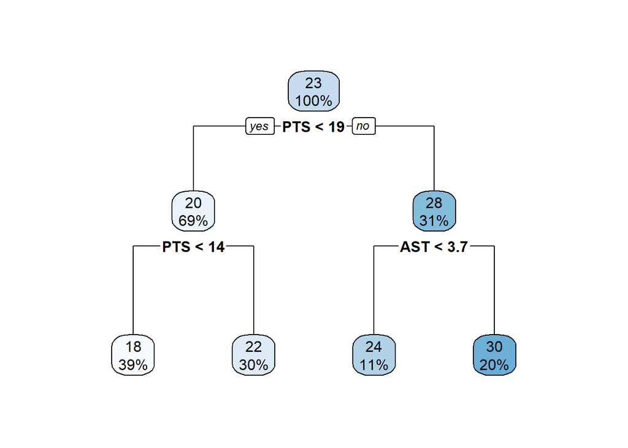

```r
rt_final_model <- extract_workflow(best_rt_test)
rt_final_model |>
  extract_fit_engine() |>
  rpart.plot::rpart.plot(roundint = FALSE)
```

It’s really interesting to me that this tree is so simple, *and* only uses offensive statistics. I know that’s what most fans focus on but I would have guess coaches (the people who decide on playing time) would have a more nuanced view which would’ve come through here.

## Random Forest Summary

For this summary, we’ll look at the relative importance of each variable (since we don’t have a single tree to analyze).

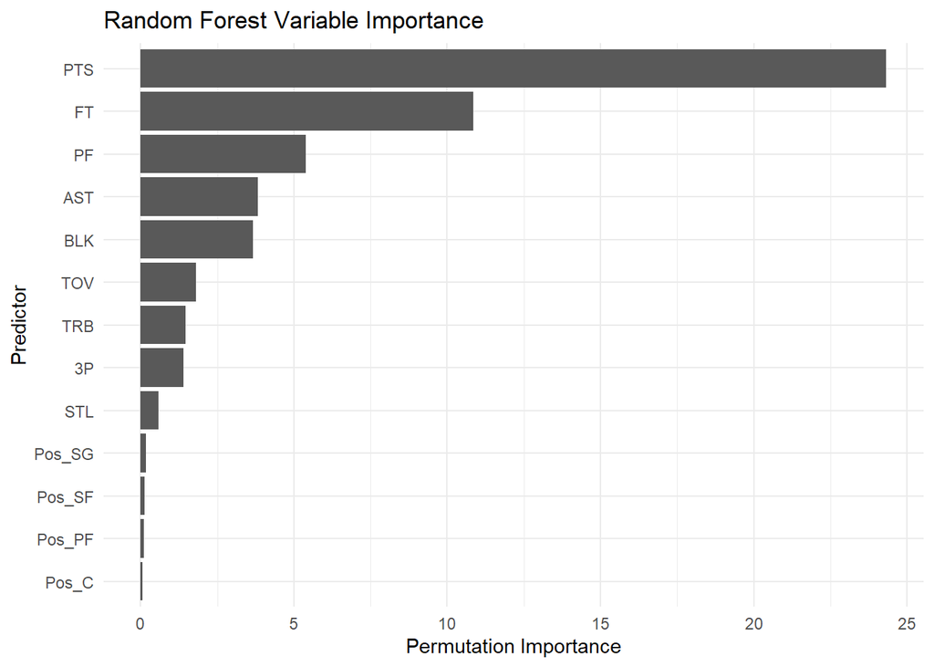

```r
rf_final_model <- best_rf_test |>
  extract_workflow() |>
  extract_fit_engine()

# Extract permutation variable importance
rf_importance <- tibble(
  term = names(rf_final_model$variable.importance),
  value = as.numeric(rf_final_model$variable.importance)
)

# Create the variable importance plot
rf_importance |>
  mutate(term = reorder(term, value)) |>
  ggplot(aes(x = term, y = value)) +
  geom_col() +
  coord_flip() +
  labs(
    title = "Random Forest Variable Importance",
    x = "Predictor",
    y = "Permutation Importance"
  ) +
  theme_minimal()
```

As before, this skews heavily to the offensive side of the ball. You have to get to the fifth variable (blocks) to get something anything related to defense. Of course, both blocks and steals are relatively rare (and therefore highly variable) events, so it’s possible that there’s simply too much noise there for that to be of much predictive value. Additionally, both blocks (accrued mostly by frontcourt players) and steals (backcourt) are relatively position specific, which might have cut down on their importance. Going back to the beginning, perhaps including “stocks” would have been a better choice. I suspect, though, that if there was something there, then the model would have picked up on that and used position to filter things first, and then use steals and/or blocks as appropriate.

Before finalizing the last best model, I’d like to note that the `rmse`‘s (~20% of the mean `MPG`) have felt high to me for all the models but I don’t trust my judgement too much. It could be that my model isn’t using the best possible predictors. Another explanation, that feels truer to me, is that defense is hard to quantify and so isn’t really captured by the data but **does** rightly play a pretty big role in coaches’ decisions.

## Fit the Best Overall Model

```r
# Rank models based on test RMSE
model_rankings <- best_fits |>
  filter(.metric == "rmse") |>
  arrange(.estimate) |>
  mutate(rank = row_number()) |>
  select(rank, model, test_rmse = .estimate)

# Display results
knitr::kable(
  model_rankings,
  digits = 2,
  caption = "Final Model Comparison Based on Test RMSE"
)
```

Final Model Comparison Based on Test RMSE

| rank | model | test_rmse |
| --- | --- | --- |
| 1 | Random Forest | 4.86 |
| 2 | Regression Tree | 5.62 |

```r
# Declaration of the overall winner!
best_model_name <- model_rankings$model[1]

best_model_name
```

```
[1] "Random Forest"
```

Finally, let’s fit the winner to the whole data set, not just the training data.

```r
# Fit the selected model using the entire dataset
set.seed(6.28)

best_overall_fit <- fit(final_rf_wf, data = min_played)

# Display the final fitted model
best_overall_fit
```

```
══ Workflow [trained] ══════════════════════════════════════════════════════════
Preprocessor: Recipe
Model: rand_forest()

── Preprocessor ────────────────────────────────────────────────────────────────
1 Recipe Step

• step_dummy()

── Model ───────────────────────────────────────────────────────────────────────
Ranger result

Call:
 ranger::ranger(x = maybe_data_frame(x), y = y, mtry = min_cols(~5L,      x), num.trees = 1000, min.node.size = min_rows(~3L, x), num.threads = 8L,      importance = "permutation", verbose = FALSE, seed = sample.int(10^5,          1))

Type:                             Regression
Number of trees:                  1000
Sample size:                      500
Number of independent variables:  13
Mtry:                             5
Target node size:                 3
Variable importance mode:         permutation
Splitrule:                        variance
OOB prediction error (MSE):       27.7347
R squared (OOB):                  0.4402748
```

Now that we have our model, fitted to the entire dataset, we could make predictions for new observations, like data from different seasons or hypothetical values selected by the user of an API.

A quick note on the next part of the project: for the examples I’ll be including at the bottom of the API, I’ll use three players from this year’s Minnesota Timberwolves roster: Jayden McDaniels, Ayo Dosunmu, and Joan Beringer. This subset represents a mix positionally (PF*, SG, and C respectively) and in terms of role (full-time starter, reserve who’s starting as an injury replacement, and full-time reserve). They also happen to be three of my favorite players at the moment.

The statistics I’ll use are their current averages (as of Nov. 27) and, for comparison’s sake, I’ll note that their actual minutes played per game and those predicted by the model.

Jayden McDaniels: (observed: 34.05 MPG, predicted: 25.5467 MPG)

Ayo Dosunmu: (observed: 31.79 MPG, predicted: 24.1035 MPG)

Joan Beringer: (observed: 16.84 MPG, predicted: 16.7442)

*Basketball Reference has Jayden listed as a power forward, but his role on the team is that of small forward. I’m sure what’s going on there.